### **Import library**

```python
import numpy as np # linear algebra
import pandas as pd # data processing, CSV file I/O (e.g. pd.read_csv)
import os
for dirname, _, filenames in os.walk('/kaggle/input'):
    for filename in filenames:
        print(os.path.join(dirname, filename))
# Data manipulation
import pandas as pd
import numpy as np

# Visualization libraries
import matplotlib.pyplot as plt
import seaborn as sns

# Machine Learning
from sklearn.model_selection import train_test_split
from sklearn.preprocessing import StandardScaler, LabelEncoder
from sklearn.ensemble import RandomForestClassifier  # UNTUK Random Forest
from sklearn.linear_model import LogisticRegression  # UNTUK Logistic Regression
from sklearn.tree import DecisionTreeClassifier      # UNTUK Decision Tree
from sklearn.neighbors import KNeighborsClassifier   # UNTUK kNN
from sklearn.svm import SVC                          # UNTUK SVM

# Evaluation metrics
from sklearn.metrics import (classification_report, confusion_matrix,
                              accuracy_score, roc_auc_score, roc_curve,
                              precision_recall_curve, precision_score, recall_score, f1_score)

# Ignore warnings for cleaner output
import warnings
warnings.filterwarnings('ignore')

# Set random seed for reproducibility
np.random.seed(42)

print("Semua library berhasil di import!")
```

```
Semua library berhasil di import!
```

# **Customer Churn Prediction**

## **Pendahuluan**

Dataset yang kami gunakan merupakan dataset customer churn dari bank ABC. **Churn** berarti suatu kondisi **ketika nasabah meninggalkan bank**. Tujuan RBL ini adalah **memprediksi nasabah mana yang mungkin akan pergi** sehingga pihak bank dapat mengambil tindakan untuk mempertahankan mereka.

### **Tahapan :**

- Input Data
- Explore data (EDA)
- Data Preprocessing (clean and prepare data)
- Build a machine learning model
- Evaluate model performance

### **Dataset Overview:**

- **10 input features**: credit_score, country, gender, age, tenure, balance, products_number, credit_card, active_member, estimated_salary
- **1 target variable**: churn (label : 1 = Berhenti, 0 = Tetap aktif)

## **Section 2: Input dan informasi data**

```python
# Load the dataset
df = pd.read_csv("Bank Customer Churn Prediction.csv")

# Display basic information
print(f"\nDataset Shape: {df.shape[0]} rows × {df.shape[1]} columns\n")

from IPython.display import HTML
HTML(df.head().to_html())
```

```
Dataset Shape: 9990 rows × 12 columns
```

|  | customer_id | credit_score | country | gender | age | tenure | balance | products_number | credit_card | active_member | estimated_salary | churn |
| --- | --- | --- | --- | --- | --- | --- | --- | --- | --- | --- | --- | --- |
| 0 | 15634602 | 619 | France | Female | 42 | 2 | 0.00 | 1 | 1 | 1 | 101348.88 | 1 |
| 1 | 15647311 | 608 | Spain | Female | 41 | 1 | 83807.86 | 1 | 0 | 1 | 112542.58 | 0 |
| 2 | 15619304 | 502 | France | Female | 42 | 8 | 159660.80 | 3 | 1 | 0 | 113931.57 | 1 |
| 3 | 15701354 | 699 | France | Female | 39 | 1 | 0.00 | 2 | 0 | 0 | 93826.63 | 0 |
| 4 | 15737888 | 850 | Spain | Female | 43 | 2 | 125510.82 | 1 | 1 | 1 | 79084.10 | 0 |

### **Informasi Ukuran Data :**

```python
# Show data types
print("\nData Types:")
print(df.dtypes)

# Show column names
print("\nColumn Names:")
for i, col in enumerate(df.columns, 1):
    print(f"{i}. {col}")
```

```
Data Types:
customer_id           int64
credit_score          int64
country              object
gender               object
age                   int64
tenure                int64
balance             float64
products_number       int64
credit_card           int64
active_member         int64
estimated_salary    float64
churn                 int64
dtype: object

Column Names:
1. customer_id
2. credit_score
3. country
4. gender
5. age
6. tenure
7. balance
8. products_number
9. credit_card
10. active_member
11. estimated_salary
12. churn
```

### **Section 3: Understanding Data Types**

Beberapa atribut pada dataset kami yaitu sebagai berikut :

| Kolom | Tipe | Deskripsi |
| --- | --- | --- |
| customer_id | Identifier | ID unik (tidak digunakan untuk prediksi) |
| credit_score | Numerik | Skor kredit nasabah (300–850) |
| country | Kategorikal | Negara: Prancis, Spanyol, atau Jerman |
| gender | Kategorikal | Jenis kelamin: Laki-laki atau Perempuan |
| age | Numerik | Usia nasabah |
| tenure | Numerik | Lama menjadi nasabah (tahun) |
| balance | Numerik | Saldo rekening |
| products_number | Numerik | Jumlah produk bank yang dimiliki |
| credit_card | Biner | Memiliki kartu kredit? (1=Ya, 0=Tidak) |
| active_member | Biner | Nasabah aktif? (1=Ya, 0=Tidak) |
| estimated_salary | Numerik | Estimasi gaji tahunan |
| churn | Target | Meninggalkan bank? (1=Ya, 0=Tidak) |

```python
print("=" * 70)
print("Ringkasan Informasi Statistik Data:")
print("=" * 70)

# Summary statistics
print("\nDeskripsi statistik:")
print(df.describe().round(2))
df.describe().round(2)

# Check for missing values
print("\nMissing Values Check:")
missing = df.isnull().sum()
print(missing)

if missing.sum() == 0:
    print("\nTidak ada missing values pada dataset ini.")
else:
    print(f"\nTotal missing values: {missing.sum()}")

# Check for duplicates
duplicates = df.duplicated().sum()
print(f"\nDuplicate Rows: {duplicates}")

# Deskripsi statistik kolom kategorikal
print("\nDeskripsi Statistik Kolom Kategorikal:")
print(df.describe(include=['object']))
```

```
======================================================================
Ringkasan Informasi Statistik Data:
======================================================================

Deskripsi statistik:
       customer_id  credit_score      age   tenure    balance  \
count      9990.00       9990.00  9990.00  9990.00    9990.00
mean   15690972.95        650.48    38.92     5.01   76508.29
std       71922.22         96.65    10.49     2.89   62400.81
min    15565701.00        350.00    18.00     0.00       0.00
25%    15628587.25        584.00    32.00     3.00       0.00
50%    15690758.00        652.00    37.00     5.00   97258.33
75%    15753243.25        717.00    44.00     7.75  127647.84
max    15815690.00        850.00    92.00    10.00  250898.09

       products_number  credit_card  active_member  estimated_salary   churn
count          9990.00      9990.00        9990.00           9990.00  9990.0
mean              1.53         0.71           0.52         100101.71     0.2
std               0.58         0.46           0.50          57514.02     0.4
min               1.00         0.00           0.00             11.58     0.0
25%               1.00         0.00           0.00          51012.47     0.0
50%               1.00         1.00           1.00         100238.11     0.0
75%               2.00         1.00           1.00         149395.88     0.0
max               4.00         1.00           1.00         199992.48     1.0

Missing Values Check:
customer_id         0
credit_score        0
country             0
gender              0
age                 0
tenure              0
balance             0
products_number     0
credit_card         0
active_member       0
estimated_salary    0
churn               0
dtype: int64

Tidak ada missing values pada dataset ini.

Duplicate Rows: 0

Deskripsi Statistik Kolom Kategorikal:
       country gender
count     9990   9990
unique       3      2
top     France   Male
freq      5007   5451
```

```python
# menampilkan deskripsi statistik dalam format HTML (tabel yang lebih rapi seperti dalam excel/spreadsheet)

from IPython.display import HTML, display

print("\nDeskripsi Statistik kolom numerik:")
display(HTML(df.describe().round(2).to_html()))

print("\nDeskripsi Statistik kolom kategorikal:")
display(HTML(df.describe(include=['object']).to_html()))
```

```
Deskripsi Statistik kolom numerik:
```

|  | customer_id | credit_score | age | tenure | balance | products_number | credit_card | active_member | estimated_salary | churn |
| --- | --- | --- | --- | --- | --- | --- | --- | --- | --- | --- |
| count | 9990.00 | 9990.00 | 9990.00 | 9990.00 | 9990.00 | 9990.00 | 9990.00 | 9990.00 | 9990.00 | 9990.0 |
| mean | 15690972.95 | 650.48 | 38.92 | 5.01 | 76508.29 | 1.53 | 0.71 | 0.52 | 100101.71 | 0.2 |
| std | 71922.22 | 96.65 | 10.49 | 2.89 | 62400.81 | 0.58 | 0.46 | 0.50 | 57514.02 | 0.4 |
| min | 15565701.00 | 350.00 | 18.00 | 0.00 | 0.00 | 1.00 | 0.00 | 0.00 | 11.58 | 0.0 |
| 25% | 15628587.25 | 584.00 | 32.00 | 3.00 | 0.00 | 1.00 | 0.00 | 0.00 | 51012.47 | 0.0 |
| 50% | 15690758.00 | 652.00 | 37.00 | 5.00 | 97258.33 | 1.00 | 1.00 | 1.00 | 100238.11 | 0.0 |
| 75% | 15753243.25 | 717.00 | 44.00 | 7.75 | 127647.84 | 2.00 | 1.00 | 1.00 | 149395.88 | 0.0 |
| max | 15815690.00 | 850.00 | 92.00 | 10.00 | 250898.09 | 4.00 | 1.00 | 1.00 | 199992.48 | 1.0 |

```
Deskripsi Statistik kolom kategorikal:
```

|  | country | gender |
| --- | --- | --- |
| count | 9990 | 9990 |
| unique | 3 | 2 |
| top | France | Male |
| freq | 5007 | 5451 |

### **Section 4: Exploratory Data Analysis (EDA)**

EDA membantu kami memahami pola data pada dataset. Visualisasi data yang dapat dibuat yaitu :

- Distribusi customers churned vs stayed
- Atribut/Fitur yang berhubungan dengan Kelas/label churn
- Distribusi dari variabel berbeda

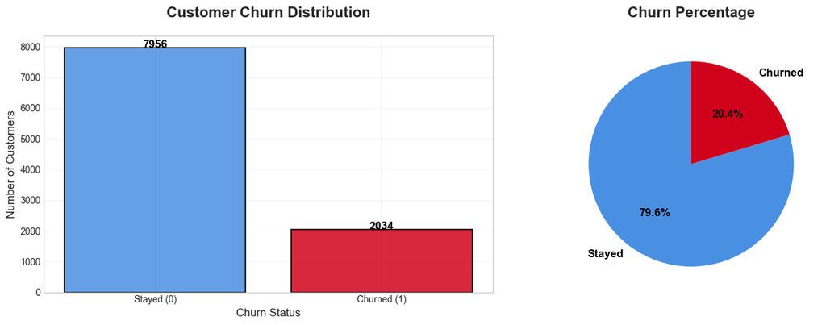

```
Persentase Nasabah diduga churn: 20.36%
  - nasabah yang tetap aktif (0) : 7956 customers (79.6%)
  - nasabah berhenti (1): 2034 customers (20.4%)
```

```python
# Style: Soft Blue Professional
plt.style.use('seaborn-v0_8-whitegrid')

fig, axes = plt.subplots(1, 2, figsize=(14, 5))

# Colors
bar_colors = ['#4a90e2', '#d0021b']     # biru lembut & merah elegan
pie_colors = ['#4a90e2', '#d0021b']

# Churn counts
churn_counts = df['churn'].value_counts()
axes[0].bar(['Stayed (0)', 'Churned (1)'], churn_counts.values,
            color=bar_colors, alpha=0.85, edgecolor='black', linewidth=1.5)
axes[0].set_title('Customer Churn Distribution', fontsize=16, fontweight='bold', pad=20)
axes[0].set_ylabel('Number of Customers', fontsize=12)
axes[0].set_xlabel('Churn Status', fontsize=12)
axes[0].grid(axis='y', alpha=0.2)

# Add value labels
for i, v in enumerate(churn_counts.values):
    axes[0].text(i, v + 1, str(v), ha='center', fontweight='bold', fontsize=12, color='black')

# Churn percentage
churn_pct = df['churn'].value_counts(normalize=True) * 100
axes[1].pie(churn_pct, labels=['Stayed', 'Churned'], autopct='%1.1f%%',
            colors=pie_colors, startangle=90,
            textprops={'fontsize': 12, 'fontweight': 'bold', 'color': 'black'})
axes[1].set_title('Churn Percentage', fontsize=16, fontweight='bold', pad=20)

plt.tight_layout()
plt.savefig('1_churn_distribution_blue.png', dpi=300, bbox_inches='tight')
plt.show()

print(f"Persentase Nasabah diduga churn: {df['churn'].mean()*100:.2f}%")
print(f"  - nasabah yang tetap aktif (0) : {churn_counts[0]} customers ({churn_pct[0]:.1f}%)")
print(f"  - nasabah berhenti (1): {churn_counts[1]} customers ({churn_pct[1]:.1f}%)")
```

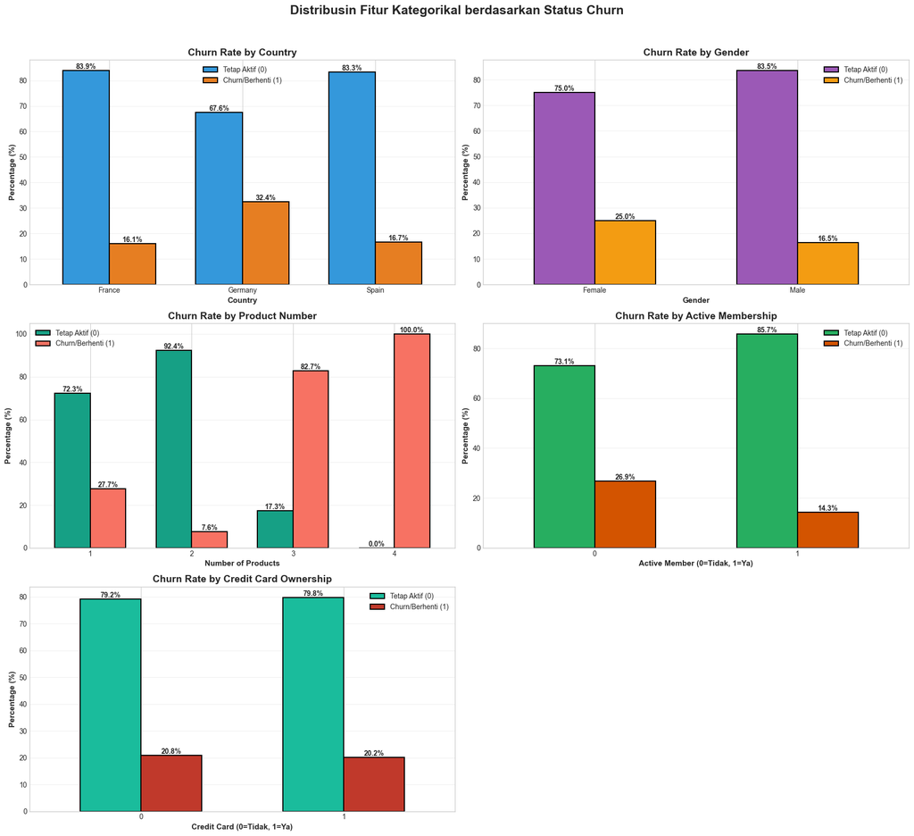

```python
plt.style.use('seaborn-v0_8-bright')

fig, axes = plt.subplots(3, 2, figsize=(18, 16))

# --- fungsi anotasi persentase ---
def add_percentage_labels(ax):
    for p in ax.patches:
        height = p.get_height()
        ax.annotate(f'{height:.1f}%',
                    (p.get_x() + p.get_width() / 2, height),
                    ha='center', va='bottom',
                    fontsize=10, fontweight='bold')

# --- 1. Churn by Country ---
country_churn = pd.crosstab(df['country'], df['churn'], normalize='index') * 100
country_churn.plot(kind='bar', ax=axes[0, 0],
                   color=['#3498db', '#e67e22'],
                   width=0.7, edgecolor='black', linewidth=1.5)

axes[0, 0].set_title('Churn Rate by Country', fontsize=14, fontweight='bold')
axes[0, 0].set_xlabel('Country', fontsize=11, fontweight='bold')
axes[0, 0].set_ylabel('Percentage (%)', fontsize=11, fontweight='bold')
axes[0, 0].legend(['Tetap Aktif (0)', 'Churn/Berhenti (1)'])
axes[0, 0].set_xticklabels(axes[0, 0].get_xticklabels(), rotation=0)
axes[0, 0].grid(axis='y', alpha=0.3)
add_percentage_labels(axes[0, 0])

# --- 2. Churn by Gender ---
gender_churn = pd.crosstab(df['gender'], df['churn'], normalize='index') * 100
gender_churn.plot(kind='bar', ax=axes[0, 1],
                  color=['#9b59b6', '#f39c12'],
                  width=0.6, edgecolor='black', linewidth=1.5)

axes[0, 1].set_title('Churn Rate by Gender', fontsize=14, fontweight='bold')
axes[0, 1].set_xlabel('Gender', fontsize=11, fontweight='bold')
axes[0, 1].set_ylabel('Percentage (%)', fontsize=11, fontweight='bold')
axes[0, 1].legend(['Tetap Aktif (0)', 'Churn/Berhenti (1)'])
axes[0, 1].set_xticklabels(axes[0, 1].get_xticklabels(), rotation=0)
axes[0, 1].grid(axis='y', alpha=0.3)
add_percentage_labels(axes[0, 1])

# --- 3. Churn by Number of Products ---
products_churn = pd.crosstab(df['products_number'], df['churn'], normalize='index') * 100
products_churn.plot(kind='bar', ax=axes[1, 0],
                    color=['#16a085', "#f77263"],
                    width=0.7, edgecolor='black', linewidth=1.5)

axes[1, 0].set_title('Churn Rate by Product Number', fontsize=14, fontweight='bold')
axes[1, 0].set_xlabel('Number of Products', fontsize=11, fontweight='bold')
axes[1, 0].set_ylabel('Percentage (%)', fontsize=11, fontweight='bold')
axes[1, 0].legend(['Tetap Aktif (0)', 'Churn/Berhenti (1)'])
axes[1, 0].set_xticklabels(axes[1, 0].get_xticklabels(), rotation=0)
axes[1, 0].grid(axis='y', alpha=0.3)
add_percentage_labels(axes[1, 0])

# --- 4. Churn by Active Membership ---
active_churn = pd.crosstab(df['active_member'], df['churn'], normalize='index') * 100
active_churn.plot(kind='bar', ax=axes[1, 1],
                  color=['#27ae60', '#d35400'],
                  width=0.6, edgecolor='black', linewidth=1.5)

axes[1, 1].set_title('Churn Rate by Active Membership', fontsize=14, fontweight='bold')
axes[1, 1].set_xlabel('Active Member (0=Tidak, 1=Ya)', fontsize=11, fontweight='bold')
axes[1, 1].set_ylabel('Percentage (%)', fontsize=11, fontweight='bold')
axes[1, 1].legend(['Tetap Aktif (0)', 'Churn/Berhenti (1)'])
axes[1, 1].set_xticklabels(axes[1, 1].get_xticklabels(), rotation=0)
axes[1, 1].grid(axis='y', alpha=0.3)
add_percentage_labels(axes[1, 1])

# --- 5. Churn by Credit Card ---
cc_churn = pd.crosstab(df['credit_card'], df['churn'], normalize='index') * 100
cc_churn.plot(kind='bar', ax=axes[2, 0],
              color=['#1abc9c', '#c0392b'],
              width=0.6, edgecolor='black', linewidth=1.5)

axes[2, 0].set_title('Churn Rate by Credit Card Ownership', fontsize=14, fontweight='bold')
axes[2, 0].set_xlabel('Credit Card (0=Tidak, 1=Ya)', fontsize=11, fontweight='bold')
axes[2, 0].set_ylabel('Percentage (%)', fontsize=11, fontweight='bold')
axes[2, 0].legend(['Tetap Aktif (0)', 'Churn/Berhenti (1)'])
axes[2, 0].set_xticklabels(axes[2, 0].get_xticklabels(), rotation=0)
axes[2, 0].grid(axis='y', alpha=0.3)
add_percentage_labels(axes[2, 0])

# Slot terakhir kosong
axes[2, 1].axis('off')

fig.suptitle('Distribusin Fitur Kategorikal berdasarkan Status Churn',
             fontsize=18, fontweight='bold', y=1.02)

plt.tight_layout()
plt.savefig('2_categorical_analysis_full.png', dpi=300, bbox_inches='tight')
plt.show()
```

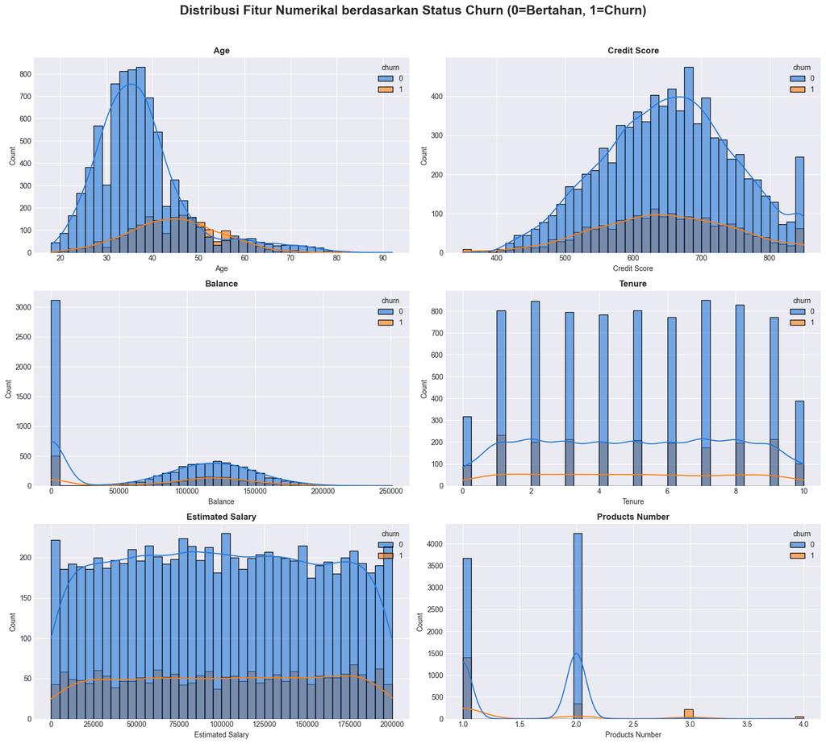

```python
plt.style.use('seaborn-v0_8-darkgrid')

# 3 baris, 2 kolom
fig, axes = plt.subplots(3, 2, figsize=(16, 14))
fig.suptitle(
    'Distribusi Fitur Numerikal berdasarkan Status Churn (0=Bertahan, 1=Churn)',
    fontsize=18, fontweight='bold', y=1.02
)

# Tambahkan products_number ke daftar fitur
numerical_features = [
    'age',
    'credit_score',
    'balance',
    'tenure',
    'estimated_salary',
    'products_number'     # <--- FITUR BARU DITAMBAHKAN
]

for idx, feature in enumerate(numerical_features):
    row = idx // 2
    col = idx % 2

    sns.histplot(
        data=df,
        x=feature,
        hue='churn',
        kde=True,
        bins=40,
        ax=axes[row, col],
        alpha=0.6,
        palette=["#2378d9", '#ff7f0e']  # biru & oranye
    )

    axes[row, col].set_title(
        feature.replace('_', ' ').title(),
        fontsize=12, fontweight='bold'
    )
    axes[row, col].set_xlabel(feature.replace('_', ' ').title(), fontsize=10)
    axes[row, col].set_ylabel('Count', fontsize=10)

# Tidak ada slot yang perlu dimatikan lagi
# axes[2, 1].axis('off')

plt.tight_layout()
plt.show()
```

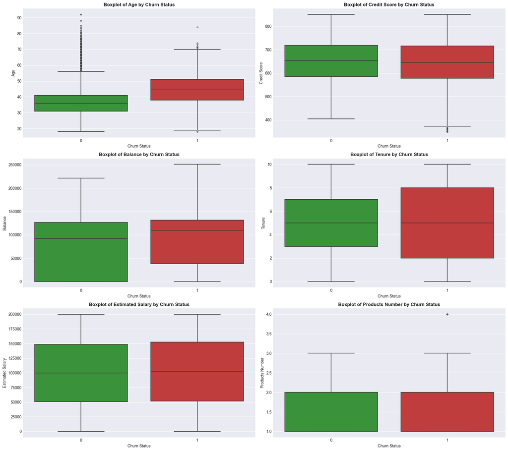

```python
# Perbandingan churn vs non-churn berdasarkan fitur numerikal
df.groupby('churn').mean(numeric_only=True)

plt.style.use('seaborn-v0_8-bright')
fig, axes = plt.subplots(3, 2, figsize=(18, 16))

numerical_features = [
    'age',
    'credit_score',
    'balance',
    'tenure',
    'estimated_salary',
    'products_number'       # <-- fitur baru ditambahkan!
]

for idx, feature in enumerate(numerical_features):
    row = idx // 2
    col = idx % 2

    sns.boxplot(
        data=df,
        x='churn',
        y=feature,
        ax=axes[row, col],
        palette=["#2ca02c", '#d62728'],  # hijau & merah
        fliersize=3,
        linewidth=1.5
    )

    axes[row, col].set_title(
        f'Boxplot of {feature.replace("_", " ").title()} by Churn Status',
        fontsize=12, fontweight='bold'
    )
    axes[row, col].set_xlabel('Churn Status', fontsize=10)
    axes[row, col].set_ylabel(feature.replace('_', ' ').title(), fontsize=10)

plt.tight_layout()
plt.show()
```

```python
# Perbandingan churn vs non-churn berdasarkan fitur numerikal
print("\nPerbandingan rata-rata fitur numerikal berdasarkan status churn:")
display(df.groupby('churn').mean(numeric_only=True).round(2).drop(columns=['customer_id']))

print ("\nPerbandingan modus tiap fitur berdasarkan status churn:")
display(df.groupby('churn').agg(lambda x: x.mode()[0]).drop(columns=['customer_id']))
```

```
Perbandingan rata-rata fitur numerikal berdasarkan status churn:
```

| churn | credit_score | age | tenure | balance | products_number | credit_card | active_member | estimated_salary |
| --- | --- | --- | --- | --- | --- | --- | --- | --- |
| 0 | 651.80 | 37.41 | 5.03 | 72761.84 | 1.54 | 0.71 | 0.55 | 99740.43 |
| 1 | 645.28 | 44.84 | 4.93 | 91162.56 | 1.48 | 0.70 | 0.36 | 101514.86 |

```
Perbandingan modus tiap fitur berdasarkan status churn:
```

| churn | credit_score | country | gender | age | tenure | balance | products_number | credit_card | active_member | estimated_salary |
| --- | --- | --- | --- | --- | --- | --- | --- | --- | --- | --- |
| 0 | 850 | France | Male | 35 | 7 | 0.0 | 2 | 1 | 1 | 24924.92 |
| 1 | 850 | Germany | Female | 46 | 1 | 0.0 | 1 | 1 | 0 | 11.58 |

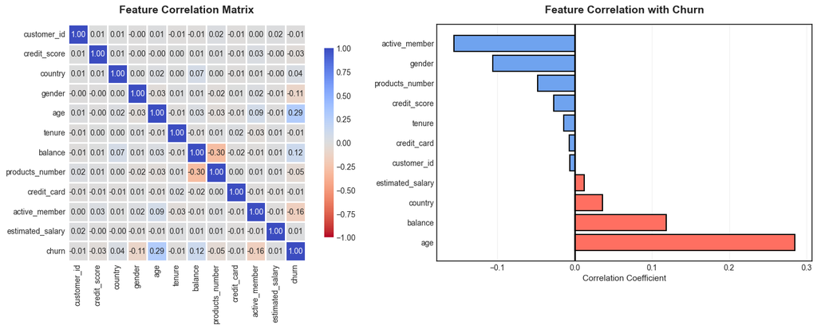

```
Top 5 Features Correlated with Churn:
age                 0.285112
balance             0.118747
country             0.036142
estimated_salary    0.012424
customer_id        -0.006360
Name: churn, dtype: float64
```

```python
plt.style.use('seaborn-v0_8-white')

# Encode categorical for correlation
df_corr = df.copy()
df_corr['gender'] = LabelEncoder().fit_transform(df_corr['gender'])
df_corr['country'] = LabelEncoder().fit_transform(df_corr['country'])

correlation_with_churn = df_corr.corr()['churn'].sort_values(ascending=False)

fig, axes = plt.subplots(1, 2, figsize=(16, 6))

# 1) Full correlation heatmap
sns.heatmap(
    df_corr.corr(), annot=True, fmt='.2f',
    cmap='coolwarm_r',      # warna baru
    center=0, square=True, linewidths=1,
    cbar_kws={"shrink": 0.8},
    ax=axes[0], vmin=-1, vmax=1
)
axes[0].set_title('Feature Correlation Matrix',
                  fontsize=14, fontweight='bold', pad=15)

# 2) Correlation with churn
colors_bar = [
    '#ff6f61' if x > 0 else '#6fa3ef'     # soft salmon vs soft blue
    for x in correlation_with_churn.drop('churn').values
]

axes[1].barh(
    range(len(correlation_with_churn) - 1),
    correlation_with_churn.drop('churn').values,
    color=colors_bar, edgecolor='black', linewidth=1.5
)

axes[1].set_yticks(range(len(correlation_with_churn) - 1))
axes[1].set_yticklabels(correlation_with_churn.drop('churn').index)
axes[1].set_xlabel('Correlation Coefficient', fontsize=11)
axes[1].set_title('Feature Correlation with Churn',
                  fontsize=14, fontweight='bold', pad=15)
axes[1].axvline(x=0, color='black', linestyle='-', linewidth=2)
axes[1].grid(axis='x', alpha=0.3)

plt.tight_layout()
plt.savefig('4_correlation_analysis.png', dpi=300, bbox_inches='tight')
plt.show()

print("\nTop 5 Features Correlated with Churn:")
print(correlation_with_churn.drop('churn').head())
```

### **Section 5: Key Insights from EDA**

Berdasarkan visualisasi yang telah dibuat, ditemukan:

#### **Temuan Penting:**

1. **Churn Rate**: Sekitar 20–25% pelanggan melakukan churn
2. **Age**: Pelanggan yang lebih tua (45+) cenderung lebih banyak melakukan churn
3. **Geography**: Jerman mungkin memiliki tingkat churn yang lebih tinggi
4. **Products**: Pelanggan dengan 3–4 produk menunjukkan pola yang tidak biasa
5. **Activity**: Anggota yang tidak aktif lebih mungkin untuk churn
6. **Balance**: Pelanggan dengan saldo tinggi menunjukkan pola menarik

#### **Mengapa Ini Penting:**

Memahami pola-pola ini membantu kita untuk:

- Mengidentifikasi pelanggan yang berisiko churn
- Memfokuskan upaya retensi
- Membangun model prediksi yang lebih baik

### **Section 6: Data Preprocessing**

Sebelum melatih model, kita perlu menyiapkan datanya:

1. **Menghapus kolom yang tidak diperlukan** (customer_id)
2. **Melakukan encoding pada variabel kategorikal** (mengubah teks menjadi angka)
3. **Membagi data** menjadi data latih dan data uji
4. **Melakukan scaling pada fitur** (menormalisasi nilai numerik)

```python
print("=" * 70)
print("DATA PREPROCESSING (Praproses Data)")
print("=" * 70)

# Membuat salinan dataset agar data asli tetap aman
df_clean = df.copy()

# Langkah 1: Hapus customer_id (tidak berguna untuk prediksi)
df_clean = df_clean.drop('customer_id', axis=1)
print("\nLangkah 1: Kolom 'customer_id' dihapus")

# Langkah 2: Encoding Gender (Biner: Female=0, Male=1)
le_gender = LabelEncoder()
df_clean['gender'] = le_gender.fit_transform(df_clean['gender'])
print("Langkah 2: Melakukan encoding pada kolom 'gender' -> Female=0, Male=1")

# Langkah 3: One-Hot Encoding untuk Country (membuat kolom dummy)
# drop_first=True digunakan untuk menghindari multikolinearitas
df_clean = pd.get_dummies(df_clean, columns=['country'], prefix='country', drop_first=True)
print("Langkah 3: Melakukan one-hot encoding pada kolom 'country'")
print(f"   Kolom baru: {[col for col in df_clean.columns if 'country' in col]}")

# Menampilkan informasi dataset yang sudah dibersihkan
print(f"\nUkuran Dataset Setelah Pembersihan: {df_clean.shape}")
print(f"\nDaftar Kolom Fitur Akhir ({len(df_clean.columns)-1} fitur):")
for i, col in enumerate([c for c in df_clean.columns if c != 'churn'], 1):
    print(f"   {i}. {col}")
```

```
======================================================================
DATA PREPROCESSING (Praproses Data)
======================================================================

Langkah 1: Kolom 'customer_id' dihapus
Langkah 2: Melakukan encoding pada kolom 'gender' -> Female=0, Male=1
Langkah 3: Melakukan one-hot encoding pada kolom 'country'
   Kolom baru: ['country_Germany', 'country_Spain']

Ukuran Dataset Setelah Pembersihan: (9990, 12)

Daftar Kolom Fitur Akhir (11 fitur):
   1. credit_score
   2. gender
   3. age
   4. tenure
   5. balance
   6. products_number
   7. credit_card
   8. active_member
   9. estimated_salary
   10. country_Germany
   11. country_Spain
```

```python
print("\n" + "=" * 70)
print("PEMBAGIAN DATA (SPLITTING DATA)")
print("=" * 70)

# Memisahkan fitur (X) dan target (y)
X = df_clean.drop('churn', axis=1)
y = df_clean['churn']

print(f"\nFitur (X): {X.shape} → {X.shape[1]} fitur × {X.shape[0]} sampel")
print(f"Target (y): {y.shape} → {y.shape[0]} label")

# Membagi data menjadi train (80%) dan test (20%)
# stratify=y memastikan proporsi churn tetap sama di kedua set
X_train, X_test, y_train, y_test = train_test_split(
    X, y,
    test_size=0.2,      # 20% untuk data testing
    random_state=42,    # Reproducible (hasil tetap)
    stratify=y          # Menjaga proporsi churn di train & test
)

print(f"\nData Training : {X_train.shape[0]} sampel ({X_train.shape[0]/len(df)*100:.1f}%)")
print(f"Data Testing  : {X_test.shape[0]} sampel ({X_test.shape[0]/len(df)*100:.1f}%)")

# Mengecek apakah stratifikasi berjalan dengan benar
print(f"\nPengecekan Distribusi Churn:")
print(f"   Training : {y_train.mean()*100:.2f}% churn")
print(f"   Testing  : {y_test.mean()*100:.2f}% churn")
print(f"   Original : {y.mean()*100:.2f}% churn (keseluruhan data)")
```

```
======================================================================
PEMBAGIAN DATA (SPLITTING DATA)
======================================================================

Fitur (X): (9990, 11) → 11 fitur × 9990 sampel
Target (y): (9990,) → 9990 label

Data Training : 7992 sampel (80.0%)
Data Testing  : 1998 sampel (20.0%)

Pengecekan Distribusi Churn:
   Training : 20.36% churn
   Testing  : 20.37% churn
   Original : 20.36% churn (keseluruhan data)
```

```python
print("\n" + "=" * 70)
print("FEATURE SCALING (Normalisasi Fitur)")
print("=" * 70)

# StandardScaler: mengubah fitur agar memiliki mean=0 dan std=1
# Ini membantu algoritma ML bekerja lebih baik dan konvergensi lebih cepat
scaler = StandardScaler()

# Fit hanya pada data training (untuk menghindari data leakage!)
X_train_scaled = scaler.fit_transform(X_train)
X_test_scaled = scaler.transform(X_test)

print("\nFitur telah dinormalisasi menggunakan StandardScaler")
print("   - Rata-rata (mean) ≈ 0")
print("   - Simpangan baku (standard deviation) ≈ 1")

# Contoh hasil scaling
print(f"\nContoh - Credit Score sebelum scaling:")
print(f"   Training: mean={X_train['credit_score'].mean():.2f}, std={X_train['credit_score'].std():.2f}")

print(f"\nContoh - Credit Score setelah scaling:")
print(f"   Training: mean={X_train_scaled[:, X.columns.get_loc('credit_score')].mean():.2f}, " +
      f"std={X_train_scaled[:, X.columns.get_loc('credit_score')].std():.2f}")

print("\nData sekarang siap digunakan untuk pemodelan Machine Learning!")
```

```
======================================================================
FEATURE SCALING (Normalisasi Fitur)
======================================================================

Fitur telah dinormalisasi menggunakan StandardScaler
   - Rata-rata (mean) ≈ 0
   - Simpangan baku (standard deviation) ≈ 1

Contoh - Credit Score sebelum scaling:
   Training: mean=650.27, std=96.68

Contoh - Credit Score setelah scaling:
   Training: mean=0.00, std=1.00

Data sekarang siap digunakan untuk pemodelan Machine Learning!
```

## Section 7: Pelatihan Model

Kita akan melatih **5 model yang berbeda** dan membandingkannya:

1. **Logistic Regression**: Model dasar yang sederhana dan mudah dijelaskan
2. **Decision Tree**: Mudah divisualisasikan dan dipahami
3. **Random Forest**: Metode ensemble yang kuat (sering memberikan performa terbaik)
4. **k-Nearest Neighbors (kNN)**: Model berbasis jarak yang bekerja baik pada pola lokal
5. **Support Vector Machine (SVM)**: Model yang kuat untuk memisahkan kelas dengan margin yang optimal

```python
print("\n" + "=" * 70)
print("PELATIHAN MODEL")
print("=" * 70)

# Dictionary untuk menyimpan model, prediksi, dan probabilitas
models = {}
predictions = {}
probabilities = {}

# 1. Logistic Regression
print("\nMelatih Model 1: Logistic Regression...")
lr_model = LogisticRegression(random_state=42, max_iter=1000)
lr_model.fit(X_train_scaled, y_train)
models['Logistic Regression'] = lr_model
predictions['Logistic Regression'] = lr_model.predict(X_test_scaled)
probabilities['Logistic Regression'] = lr_model.predict_proba(X_test_scaled)[:, 1]
print("Selesai!")

# 2. Decision Tree
print("\nMelatih Model 2: Decision Tree...")
dt_model = DecisionTreeClassifier(max_depth=5, random_state=42)
dt_model.fit(X_train_scaled, y_train)
models['Decision Tree'] = dt_model
predictions['Decision Tree'] = dt_model.predict(X_test_scaled)
probabilities['Decision Tree'] = dt_model.predict_proba(X_test_scaled)[:, 1]
print("Selesai!")

# 3. Random Forest
print("\nMelatih Model 3: Random Forest...")
rf_model = RandomForestClassifier(n_estimators=100, max_depth=10,
                                  random_state=42, n_jobs=-1)
rf_model.fit(X_train_scaled, y_train)
models['Random Forest'] = rf_model
predictions['Random Forest'] = rf_model.predict(X_test_scaled)
probabilities['Random Forest'] = rf_model.predict_proba(X_test_scaled)[:, 1]
print("Selesai!")

# 4. k-Nearest Neighbors (kNN)
print("\nMelatih Model 4: k-Nearest Neighbors (kNN)...")
knn_model = KNeighborsClassifier(n_neighbors=5)
knn_model.fit(X_train_scaled, y_train)
models['kNN'] = knn_model
predictions['kNN'] = knn_model.predict(X_test_scaled)
probabilities['kNN'] = knn_model.predict_proba(X_test_scaled)[:, 1]
print("Selesai!")

# 5. Support Vector Machine (SVM)
print("\nMelatih Model 5: Support Vector Machine (SVM)...")
svm_model = SVC(kernel='rbf', probability=True, random_state=42)
svm_model.fit(X_train_scaled, y_train)
models['SVM'] = svm_model
predictions['SVM'] = svm_model.predict(X_test_scaled)
probabilities['SVM'] = svm_model.predict_proba(X_test_scaled)[:, 1]
print("Selesai!")

print("\nSemua model berhasil dilatih!")
```

```
======================================================================
PELATIHAN MODEL
======================================================================

Melatih Model 1: Logistic Regression...
Selesai!

Melatih Model 2: Decision Tree...
Selesai!

Melatih Model 3: Random Forest...
Selesai!

Melatih Model 4: k-Nearest Neighbors (kNN)...
Selesai!

Melatih Model 5: Support Vector Machine (SVM)...
Selesai!

Semua model berhasil dilatih!
```

## Section 8: Evaluasi Model

Sekarang kita akan mengevaluasi seberapa baik setiap model bekerja menggunakan:

- **Accuracy**: Persentase prediksi yang benar
- **Precision**: Dari seluruh prediksi churn, berapa banyak yang benar-benar churn?
- **Recall**: Dari seluruh data churn yang sebenarnya, berapa banyak yang berhasil kita tangkap?
- **ROC-AUC**: Kualitas keseluruhan model (0.5 = acak, 1.0 = sempurna)

```python
print("\n" + "=" * 70)
print("EVALUASI & PERBANDINGAN MODEL")
print("=" * 70)

# Membuat dataframe perbandingan performa model
results = []

for model_name in models.keys():
    accuracy = accuracy_score(y_test, predictions[model_name])
    roc_auc = roc_auc_score(y_test, probabilities[model_name])

    results.append({
        'Model': model_name,
        'Akurasi': f"{accuracy*100:.2f}%",
        'ROC-AUC': f"{roc_auc:.4f}"
    })

results_df = pd.DataFrame(results)
print("\nRingkasan Performa Model:")
print(results_df.to_string(index=False))

# Menentukan model terbaik berdasarkan ROC-AUC
best_model_name = max(probabilities.keys(),
                      key=lambda x: roc_auc_score(y_test, probabilities[x]))

print(f"\nModel Terbaik Berdasarkan ROC-AUC: {best_model_name}")
```

```
======================================================================
EVALUASI & PERBANDINGAN MODEL
======================================================================

Ringkasan Performa Model:
              Model Akurasi ROC-AUC
Logistic Regression  81.08%  0.7713
      Decision Tree  85.29%  0.8479
      Random Forest  86.94%  0.8666
                kNN  82.93%  0.7600
                SVM  86.19%  0.8298

Model Terbaik Berdasarkan ROC-AUC: Random Forest
```

```python
# ===========================
# HASIL LOGISTIC REGRESSION
# ===========================

print("\n" + "="*70)
print("HASIL DETAIL: Logistic Regression")
print("="*70)

# Prediksi
lr_pred = lr_model.predict(X_test_scaled)

# Classification Report
print("\nLaporan Klasifikasi:")
print(classification_report(
    y_test, lr_pred,
    target_names=['Tetap (0)', 'Churn (1)'],
    digits=3
))

# Confusion Matrix (manual print)
cm_lr = confusion_matrix(y_test, lr_pred)

print("\nConfusion Matrix (Matriks Kebingungan):")
print("                      Prediksi")
print("                 Tetap      Churn")
print(f"Actual Tetap     {cm_lr[0,0]:4d}      {cm_lr[0,1]:4d}")
print(f"Actual Churn     {cm_lr[1,0]:4d}      {cm_lr[1,1]:4d}")

# Additional Metrics
tn, fp, fn, tp = cm_lr.ravel()
specificity = tn / (tn + fp)
sensitivity = tp / (tp + fn)

print("\nMetrik Tambahan:")
print(f"   True Negatives (TN / Benar Tetap):      {tn}")
print(f"   False Positives (FP / Salah Churn):     {fp}")
print(f"   False Negatives (FN / Salah Tetap):     {fn}")
print(f"   True Positives (TP / Benar Churn):      {tp}")
print(f"   Spesifisitas (Specificity):             {specificity:.3f}")
print(f"   Sensitivitas/Recall:                    {sensitivity:.3f}")
```

```
======================================================================
HASIL DETAIL: Logistic Regression
======================================================================

Laporan Klasifikasi:
              precision    recall  f1-score   support

   Tetap (0)      0.825     0.969     0.891      1591
   Churn (1)      0.612     0.194     0.295       407

    accuracy                          0.811      1998
   macro avg      0.718     0.581     0.593      1998
weighted avg      0.781     0.811     0.769      1998


Confusion Matrix (Matriks Kebingungan):
                      Prediksi
                 Tetap      Churn
Actual Tetap     1541        50
Actual Churn      328        79

Metrik Tambahan:
   True Negatives (TN / Benar Tetap):      1541
   False Positives (FP / Salah Churn):     50
   False Negatives (FN / Salah Tetap):     328
   True Positives (TP / Benar Churn):      79
   Spesifisitas (Specificity):             0.969
   Sensitivitas/Recall:                    0.194
```

```python
# ===========================
# HASIL DECISION TREE
# ===========================

print("\n" + "="*70)
print("HASIL DETAIL: Decision Tree")
print("="*70)

# Prediksi
dt_pred = dt_model.predict(X_test_scaled)

# Laporan Klasifikasi
print("\nLaporan Klasifikasi:")
print(classification_report(
    y_test, dt_pred,
    target_names=['Tetap (0)', 'Churn (1)'],
    digits=3
))

# Confusion Matrix (manual print)
cm_dt = confusion_matrix(y_test, dt_pred)

print("\nConfusion Matrix (Matriks Kebingungan):")
print("                      Prediksi")
print("                 Tetap      Churn")
print(f"Actual Tetap     {cm_dt[0,0]:4d}      {cm_dt[0,1]:4d}")
print(f"Actual Churn     {cm_dt[1,0]:4d}      {cm_dt[1,1]:4d}")

# Metrik Tambahan
tn, fp, fn, tp = cm_dt.ravel()
specificity = tn / (tn + fp) if (tn + fp) != 0 else 0
sensitivity = tp / (tp + fn) if (tp + fn) != 0 else 0

print("\nMetrik Tambahan:")
print(f"   True Negatives (TN / Benar Tetap):      {tn}")
print(f"   False Positives (FP / Salah Churn):     {fp}")
print(f"   False Negatives (FN / Salah Tetap):     {fn}")
print(f"   True Positives (TP / Benar Churn):      {tp}")
print(f"   Spesifisitas (Specificity):             {specificity:.3f}")
print(f"   Sensitivitas / Recall:                  {sensitivity:.3f}")
```

```
======================================================================
HASIL DETAIL: Decision Tree
======================================================================

Laporan Klasifikasi:
              precision    recall  f1-score   support

   Tetap (0)      0.862     0.971     0.913      1591
   Churn (1)      0.776     0.391     0.520       407

    accuracy                          0.853      1998
   macro avg      0.819     0.681     0.716      1998
weighted avg      0.844     0.853     0.833      1998


Confusion Matrix (Matriks Kebingungan):
                      Prediksi
                 Tetap      Churn
Actual Tetap     1545        46
Actual Churn      248       159

Metrik Tambahan:
   True Negatives (TN / Benar Tetap):      1545
   False Positives (FP / Salah Churn):     46
   False Negatives (FN / Salah Tetap):     248
   True Positives (TP / Benar Churn):      159
   Spesifisitas (Specificity):             0.971
   Sensitivitas / Recall:                  0.391
```

```python
print("\n" + "=" * 70)
print(f"HASIL DETAIL: {best_model_name}")
print("=" * 70)

best_pred = predictions[best_model_name]
best_proba = probabilities[best_model_name]

# Laporan Klasifikasi
print("\nLaporan Klasifikasi:")
print(classification_report(
    y_test, best_pred,
    target_names=['Tetap (0)', 'Churn (1)'],
    digits=3
))

# Confusion Matrix
cm = confusion_matrix(y_test, best_pred)

print("\nConfusion Matrix (Matriks Kebingungan):")
print(f"                      Prediksi")
print(f"                 Tetap      Churn")
print(f"Actual Tetap     {cm[0,0]:4d}      {cm[0,1]:4d}")
print(f"Actual Churn     {cm[1,0]:4d}      {cm[1,1]:4d}")

# Hitungan metrik tambahan
tn, fp, fn, tp = cm.ravel()
specificity = tn / (tn + fp) if (tn + fp) != 0 else 0
sensitivity = tp / (tp + fn) if (tp + fn) != 0 else 0

print(f"\nMetrik Tambahan:")
print(f"   True Negatives (TN / Benar Tetap):     {tn}")
print(f"   False Positives (FP / Salah Churn):    {fp}")
print(f"   False Negatives (FN / Salah Tetap):    {fn}")
print(f"   True Positives (TP / Benar Churn):     {tp}")
print(f"   Spesifisitas (Specificity):            {specificity:.3f}  (prediksi 'Tetap' yang benar)")
print(f"   Sensitivitas / Recall:                 {sensitivity:.3f}  (prediksi 'Churn' yang benar)")
```

```
======================================================================
HASIL DETAIL: Random Forest
======================================================================

Laporan Klasifikasi:
              precision    recall  f1-score   support

   Tetap (0)      0.875     0.975     0.922      1591
   Churn (1)      0.823     0.457     0.588       407

    accuracy                          0.869      1998
   macro avg      0.849     0.716     0.755      1998
weighted avg      0.865     0.869     0.854      1998


Confusion Matrix (Matriks Kebingungan):
                      Prediksi
                 Tetap      Churn
Actual Tetap     1551        40
Actual Churn      221       186

Metrik Tambahan:
   True Negatives (TN / Benar Tetap):     1551
   False Positives (FP / Salah Churn):    40
   False Negatives (FN / Salah Tetap):    221
   True Positives (TP / Benar Churn):     186
   Spesifisitas (Specificity):            0.975  (prediksi 'Tetap' yang benar)
   Sensitivitas / Recall:                 0.457  (prediksi 'Churn' yang benar)
```

```python
# ===========================
# HASIL k-NEAREST NEIGHBORS
# ===========================

print("\n" + "="*70)
print("HASIL DETAIL: k-Nearest Neighbors (kNN)")
print("="*70)

# Prediksi
knn_pred = knn_model.predict(X_test_scaled)

# Laporan Klasifikasi
print("\nLaporan Klasifikasi:")
print(classification_report(
    y_test, knn_pred,
    target_names=['Tetap (0)', 'Churn (1)'],
    digits=3
))

# Confusion Matrix
cm_knn = confusion_matrix(y_test, knn_pred)

print("\nConfusion Matrix (Matriks Kebingungan):")
print("                      Prediksi")
print("                 Tetap      Churn")
print(f"Actual Tetap     {cm_knn[0,0]:4d}      {cm_knn[0,1]:4d}")
print(f"Actual Churn     {cm_knn[1,0]:4d}      {cm_knn[1,1]:4d}")

# Metrik Tambahan
tn, fp, fn, tp = cm_knn.ravel()
specificity = tn / (tn + fp) if (tn + fp) != 0 else 0
sensitivity = tp / (tp + fn) if (tp + fn) != 0 else 0

print("\nMetrik Tambahan:")
print(f"   True Negatives (TN / Benar Tetap):      {tn}")
print(f"   False Positives (FP / Salah Churn):     {fp}")
print(f"   False Negatives (FN / Salah Tetap):     {fn}")
print(f"   True Positives (TP / Benar Churn):      {tp}")
print(f"   Spesifisitas (Specificity):             {specificity:.3f}")
print(f"   Sensitivitas/Recall:                    {sensitivity:.3f}")
```

```
======================================================================
HASIL DETAIL: k-Nearest Neighbors (kNN)
======================================================================

Laporan Klasifikasi:
              precision    recall  f1-score   support

   Tetap (0)      0.852     0.952     0.899      1591
   Churn (1)      0.650     0.351     0.456       407

    accuracy                          0.829      1998
   macro avg      0.751     0.651     0.677      1998
weighted avg      0.810     0.829     0.809      1998


Confusion Matrix (Matriks Kebingungan):
                      Prediksi
                 Tetap      Churn
Actual Tetap     1514        77
Actual Churn      264       143

Metrik Tambahan:
   True Negatives (TN / Benar Tetap):      1514
   False Positives (FP / Salah Churn):     77
   False Negatives (FN / Salah Tetap):     264
   True Positives (TP / Benar Churn):      143
   Spesifisitas (Specificity):             0.952
   Sensitivitas/Recall:                    0.351
```

```python
# ===========================
# HASIL SUPPORT VECTOR MACHINE
# ===========================

print("\n" + "="*70)
print("HASIL DETAIL: Support Vector Machine (SVM)")
print("="*70)

# Prediksi
svm_pred = svm_model.predict(X_test_scaled)

# Laporan Klasifikasi
print("\nLaporan Klasifikasi:")
print(classification_report(
    y_test, svm_pred,
    target_names=['Tetap (0)', 'Churn (1)'],
    digits=3
))

# Confusion Matrix
cm_svm = confusion_matrix(y_test, svm_pred)

print("\nConfusion Matrix (Matriks Kebingungan):")
print("                      Prediksi")
print("                 Tetap      Churn")
print(f"Actual Tetap     {cm_svm[0,0]:4d}      {cm_svm[0,1]:4d}")
print(f"Actual Churn     {cm_svm[1,0]:4d}      {cm_svm[1,1]:4d}")

# Metrik Tambahan
tn, fp, fn, tp = cm_svm.ravel()
specificity = tn / (tn + fp) if (tn + fp) != 0 else 0
sensitivity = tp / (tp + fn) if (tp + fn) != 0 else 0

print("\nMetrik Tambahan:")
print(f"   True Negatives (TN / Benar Tetap):      {tn}")
print(f"   False Positives (FP / Salah Churn):     {fp}")
print(f"   False Negatives (FN / Salah Tetap):     {fn}")
print(f"   True Positives (TP / Benar Churn):      {tp}")
print(f"   Spesifisitas (Specificity):             {specificity:.3f}")
print(f"   Sensitivitas/Recall:                    {sensitivity:.3f}")
```

```
======================================================================
HASIL DETAIL: Support Vector Machine (SVM)
======================================================================

Laporan Klasifikasi:
              precision    recall  f1-score   support

   Tetap (0)      0.863     0.982     0.919      1591
   Churn (1)      0.847     0.393     0.537       407

    accuracy                          0.862      1998
   macro avg      0.855     0.687     0.728      1998
weighted avg      0.860     0.862     0.841      1998


Confusion Matrix (Matriks Kebingungan):
                      Prediksi
                 Tetap      Churn
Actual Tetap     1562        29
Actual Churn      247       160

Metrik Tambahan:
   True Negatives (TN / Benar Tetap):      1562
   False Positives (FP / Salah Churn):     29
   False Negatives (FN / Salah Tetap):     247
   True Positives (TP / Benar Churn):      160
   Spesifisitas (Specificity):             0.982
   Sensitivitas/Recall:                    0.393
```

```
======================================================================
VISUALISASI CONFUSION MATRIX
======================================================================

Menampilkan Confusion Matrix untuk model: Logistic Regression
```

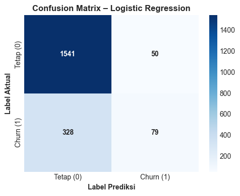

```
Menampilkan Confusion Matrix untuk model: Decision Tree
```

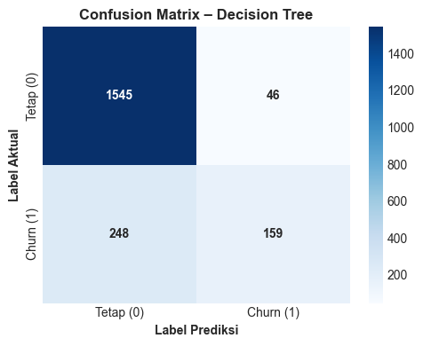

```
Menampilkan Confusion Matrix untuk model: Random Forest
```

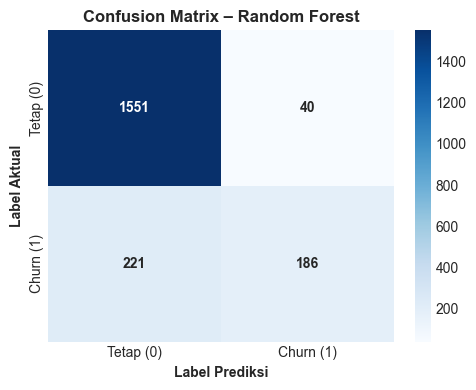

```
Menampilkan Confusion Matrix untuk model: kNN
```

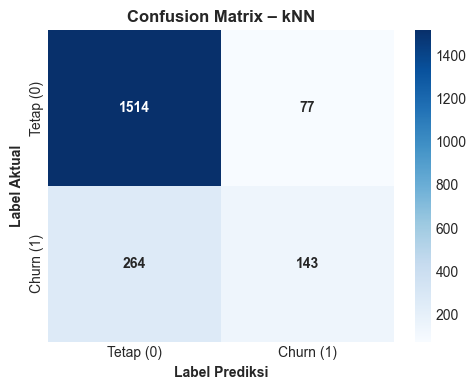

```
Menampilkan Confusion Matrix untuk model: SVM
```

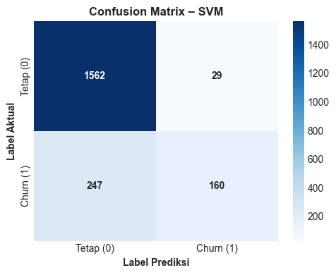

```python
# VISUALISASI CONFUSION MATRIX (SEMUA MODEL)

def plot_cm_visual(cm, model_name):
    plt.figure(figsize=(5,4))
    sns.heatmap(cm, annot=True, fmt="d", cmap="Blues",
                annot_kws={'fontweight': 'bold'},
                xticklabels=["Tetap (0)", "Churn (1)"],
                yticklabels=["Tetap (0)", "Churn (1)"])
    plt.title(f"Confusion Matrix – {model_name}", fontweight='bold')
    plt.xlabel("Label Prediksi", fontweight='bold')
    plt.ylabel("Label Aktual", fontweight='bold')
    plt.tight_layout()
    plt.show()


print("\n" + "="*70)
print("VISUALISASI CONFUSION MATRIX")
print("="*70)

for model_name in models.keys():
    print(f"\nMenampilkan Confusion Matrix untuk model: {model_name}")
    cm = confusion_matrix(y_test, predictions[model_name])
    plot_cm_visual(cm, model_name)
```

[figure not shown]

```python
# Style 6: Dasbor Perbandingan Performa Model
plt.style.use('seaborn-v0_8-darkgrid')

fig, axes = plt.subplots(2, 2, figsize=(16, 12))
fig.suptitle('Dasbor Perbandingan Performa Model',
             fontsize=18, fontweight='bold', y=0.995)

# 1. Perbandingan Akurasi
model_names = list(models.keys())
accuracies = [accuracy_score(y_test, predictions[m]) * 100 for m in model_names]
colors_acc = ['#3498db', '#e67e22', '#2ecc71', '#9b59b6', '#f39c12']

axes[0, 0].barh(model_names, accuracies, color=colors_acc,
                edgecolor='black', linewidth=2, alpha=0.8)
axes[0, 0].set_xlabel('Akurasi (%)', fontsize=12, fontweight='bold')
axes[0, 0].set_title('Perbandingan Akurasi Model', fontsize=14, fontweight='bold', pad=15)
axes[0, 0].set_xlim([0, 100])

for i, v in enumerate(accuracies):
    axes[0, 0].text(v + 1, i, f'{v:.2f}%', va='center', fontweight='bold')

axes[0, 0].grid(axis='x', alpha=0.3)

# 2. Kurva ROC
for model_name, color in zip(model_names, colors_acc):
    fpr, tpr, _ = roc_curve(y_test, probabilities[model_name])
    auc_score = roc_auc_score(y_test, probabilities[model_name])
    axes[0, 1].plot(fpr, tpr, color=color, lw=3,
                    label=f'{model_name} (AUC={auc_score:.3f})')

axes[0, 1].plot([0, 1], [0, 1], 'k--', lw=2, label='Acak (AUC=0.500)')
axes[0, 1].set_xlabel('False Positive Rate (FPR)', fontsize=12, fontweight='bold')
axes[0, 1].set_ylabel('True Positive Rate (TPR)', fontsize=12, fontweight='bold')
axes[0, 1].set_title('Kurva ROC', fontsize=14, fontweight='bold', pad=15)
axes[0, 1].legend(loc='lower right', fontsize=10)
axes[0, 1].grid(alpha=0.3)

# 3. Confusion Matrix untuk Model Terbaik
sns.heatmap(cm, annot=True, fmt='d', cmap='Blues', cbar=True,
            xticklabels=['Tetap (0)', 'Churn (1)'],
            yticklabels=['Tetap (0)', 'Churn (1)'],
            ax=axes[1, 0], linewidths=2, linecolor='black',
            annot_kws={'fontsize': 14, 'fontweight': 'bold'})

axes[1, 0].set_title(f'Confusion Matrix - {best_model_name}',
                     fontsize=14, fontweight='bold', pad=15)
axes[1, 0].set_ylabel('Aktual', fontsize=12, fontweight='bold')
axes[1, 0].set_xlabel('Prediksi', fontsize=12, fontweight='bold')

# 4. Kurva Precision-Recall
for model_name, color in zip(model_names, colors_acc):
    precision, recall, _ = precision_recall_curve(y_test, probabilities[model_name])
    axes[1, 1].plot(recall, precision, color=color, lw=3, label=model_name)

axes[1, 1].set_xlabel('Recall', fontsize=12, fontweight='bold')
axes[1, 1].set_ylabel('Precision', fontsize=12, fontweight='bold')
axes[1, 1].set_title('Kurva Precision-Recall', fontsize=14, fontweight='bold', pad=15)
axes[1, 1].legend(loc='lower left', fontsize=10)
axes[1, 1].grid(alpha=0.3)
axes[1, 1].set_xlim([0, 1])
axes[1, 1].set_ylim([0, 1])

plt.tight_layout()
plt.savefig('6_model_comparison_dashboard.png', dpi=300, bbox_inches='tight')
plt.show()
```

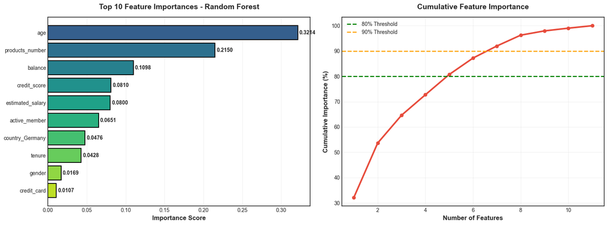

```
Top 5 Most Important Features:
   age: 0.3214
   products_number: 0.2150
   balance: 0.1098
   credit_score: 0.0810
   estimated_salary: 0.0800
```

```python
# Style 7: Gradient Feature Importance
plt.style.use('seaborn-v0_8-white')

fig, axes = plt.subplots(1, 2, figsize=(16, 6))

# Random Forest Feature Importance
rf_importance = pd.DataFrame({
    'feature': X.columns,
    'importance': rf_model.feature_importances_
}).sort_values('importance', ascending=False)

# Top 10 features
top10 = rf_importance.head(10)
colors_gradient = plt.cm.viridis(np.linspace(0.3, 0.9, len(top10)))

axes[0].barh(range(len(top10)), top10['importance'],
             color=colors_gradient, edgecolor='black', linewidth=1.5)
axes[0].set_yticks(range(len(top10)))
axes[0].set_yticklabels(top10['feature'])
axes[0].set_xlabel('Importance Score', fontsize=12, fontweight='bold')
axes[0].set_title('Top 10 Feature Importances - Random Forest',
                  fontsize=14, fontweight='bold', pad=15)
axes[0].invert_yaxis()
axes[0].grid(axis='x', alpha=0.3)

# Add value labels
for i, v in enumerate(top10['importance']):
    axes[0].text(v + 0.002, i, f'{v:.4f}', va='center', fontweight='bold')

# Cumulative importance
rf_importance['cumulative'] = rf_importance['importance'].cumsum()
axes[1].plot(range(1, len(rf_importance)+1),
             rf_importance['cumulative'].values * 100,
             color='#e74c3c', linewidth=3, marker='o', markersize=6)
axes[1].axhline(y=80, color='green', linestyle='--', linewidth=2, label='80% Threshold')
axes[1].axhline(y=90, color='orange', linestyle='--', linewidth=2, label='90% Threshold')
axes[1].set_xlabel('Number of Features', fontsize=12, fontweight='bold')
axes[1].set_ylabel('Cumulative Importance (%)', fontsize=12, fontweight='bold')
axes[1].set_title('Cumulative Feature Importance', fontsize=14, fontweight='bold', pad=15)
axes[1].legend(fontsize=10)
axes[1].grid(alpha=0.3)

plt.tight_layout()
plt.savefig('7_feature_importance.png', dpi=300, bbox_inches='tight')
plt.show()

print("\nTop 5 Most Important Features:")
for idx, row in rf_importance.head(5).iterrows():
    print(f"   {row['feature']}: {row['importance']:.4f}")
```

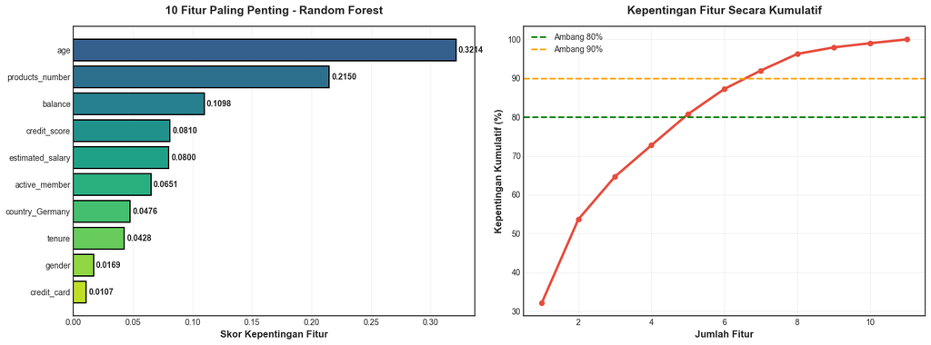

```
5 Fitur Paling Penting:
   age: 0.3214
   products_number: 0.2150
   balance: 0.1098
   credit_score: 0.0810
   estimated_salary: 0.0800
```

```python
# Style 7: Gradient Feature Importance
plt.style.use('seaborn-v0_8-white')

fig, axes = plt.subplots(1, 2, figsize=(16, 6))

# Random Forest Feature Importance
rf_importance = pd.DataFrame({
    'feature': X.columns,
    'importance': rf_model.feature_importances_
}).sort_values('importance', ascending=False)

# Top 10 fitur
top10 = rf_importance.head(10)
colors_gradient = plt.cm.viridis(np.linspace(0.3, 0.9, len(top10)))

# Plot 1: Top 10
axes[0].barh(range(len(top10)), top10['importance'],
             color=colors_gradient, edgecolor='black', linewidth=1.5)
axes[0].set_yticks(range(len(top10)))
axes[0].set_yticklabels(top10['feature'])
axes[0].set_xlabel('Skor Kepentingan Fitur', fontsize=12, fontweight='bold')
axes[0].set_title('10 Fitur Paling Penting - Random Forest',
                  fontsize=14, fontweight='bold', pad=15)
axes[0].invert_yaxis()
axes[0].grid(axis='x', alpha=0.3)

# Tambahkan label angka
for i, v in enumerate(top10['importance']):
    axes[0].text(v + 0.002, i, f'{v:.4f}', va='center', fontweight='bold')

# Plot 2: Cumulative importance
rf_importance['cumulative'] = rf_importance['importance'].cumsum()
axes[1].plot(range(1, len(rf_importance)+1),
             rf_importance['cumulative'].values * 100,
             color='#e74c3c', linewidth=3, marker='o', markersize=6)

axes[1].axhline(y=80, color='green', linestyle='--', linewidth=2,
                label='Ambang 80%')
axes[1].axhline(y=90, color='orange', linestyle='--', linewidth=2,
                label='Ambang 90%')

axes[1].set_xlabel('Jumlah Fitur', fontsize=12, fontweight='bold')
axes[1].set_ylabel('Kepentingan Kumulatif (%)', fontsize=12, fontweight='bold')
axes[1].set_title('Kepentingan Fitur Secara Kumulatif',
                  fontsize=14, fontweight='bold', pad=15)
axes[1].legend(fontsize=10)
axes[1].grid(alpha=0.3)

plt.tight_layout()
plt.savefig('7_feature_importance.png', dpi=300, bbox_inches='tight')
plt.show()

# Output Print
print("\n5 Fitur Paling Penting:")
for idx, row in rf_importance.head(5).iterrows():
    print(f"   {row['feature']}: {row['importance']:.4f}")
```

## Section 9: Memahami Hasil

### Apa Arti dari Metrik-Metrik Ini?

**Interpretasi Confusion Matrix:**

- **True Negatives (TN)**: Prediksi "Tetap" yang benar
- **False Positives (FP)**: Diprediksi "Churn", tetapi sebenarnya tetap (Kesalahan Tipe I)
- **False Negatives (FN)**: Diprediksi "Tetap", tetapi sebenarnya churn (Kesalahan Tipe II)
- **True Positives (TP)**: Prediksi "Churn" yang benar

**Kesalahan Mana yang Lebih Buruk?**

- **False Negatives** biasanya lebih buruk bagi bank — karena bank gagal mendeteksi nasabah yang akan churn, menyebabkan kehilangan pendapatan
- **False Positives** mengakibatkan biaya tambahan untuk melakukan upaya retensi, tetapi dapat mencegah kehilangan pendapatan

```
======================================================================
ANALISIS DAMPAK BISNIS
======================================================================

Metrik Bisnis (Berdasarkan Data Test):

Dampak Pendapatan:
   Jumlah nasabah yang terdeteksi akan churn: 160
   Potensi nasabah yang diselamatkan (30% berhasil): 48
   Pendapatan yang terselamatkan: Rp2,400,000
   Pendapatan hilang (nasabah churn yang tidak terdeteksi): Rp12,350,000

Analisis Biaya:
   Jumlah kampanye retensi dikirim: 189
   Total biaya retensi: Rp94,500

Dampak Bisnis Bersih:
   Keuntungan Bersih (Net Benefit): Rp2,305,500
   ROI: 2439.7%
```

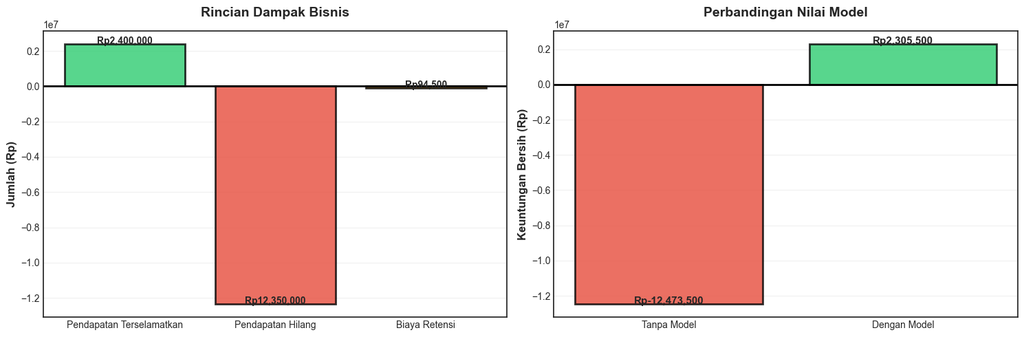

```python
print("\n" + "=" * 70)
print("ANALISIS DAMPAK BISNIS")
print("=" * 70)

# Asumsi untuk perhitungan dampak bisnis
avg_customer_value = 50000       # Nilai rata-rata saldo nasabah
retention_cost = 500             # Biaya retensi per nasabah
retention_success_rate = 0.3     # 30% upaya retensi berhasil

# Hitung metrik bisnis
tn, fp, fn, tp = cm.ravel()

# Biaya dan Pendapatan
saved_customers = int(tp * retention_success_rate)
retention_spending = (tp + fp) * retention_cost
revenue_saved = saved_customers * avg_customer_value
lost_revenue = fn * avg_customer_value
net_benefit = revenue_saved - retention_spending

print(f"\nMetrik Bisnis (Berdasarkan Data Test):")
print(f"\nDampak Pendapatan:")
print(f"   Jumlah nasabah yang terdeteksi akan churn: {tp}")
print(f"   Potensi nasabah yang diselamatkan (30% berhasil): {saved_customers}")
print(f"   Pendapatan yang terselamatkan: Rp{revenue_saved:,.0f}")
print(f"   Pendapatan hilang (nasabah churn yang tidak terdeteksi): Rp{lost_revenue:,.0f}")

print(f"\nAnalisis Biaya:")
print(f"   Jumlah kampanye retensi dikirim: {tp + fp}")
print(f"   Total biaya retensi: Rp{retention_spending:,.0f}")

print(f"\nDampak Bisnis Bersih:")
print(f"   Keuntungan Bersih (Net Benefit): Rp{net_benefit:,.0f}")
print(f"   ROI: {(net_benefit/retention_spending)*100:.1f}%")

# Visualisasi dampak bisnis
fig, axes = plt.subplots(1, 2, figsize=(15, 5))

# Breakdown dampak bisnis
impact_categories = ['Pendapatan Terselamatkan', 'Pendapatan Hilang', 'Biaya Retensi']
impact_values = [revenue_saved, -lost_revenue, -retention_spending]
impact_colors = ['#2ecc71', '#e74c3c', '#f39c12']

axes[0].bar(impact_categories, impact_values, color=impact_colors,
            edgecolor='black', linewidth=2, alpha=0.8)
axes[0].axhline(y=0, color='black', linewidth=2)
axes[0].set_ylabel('Jumlah (Rp)', fontsize=12, fontweight='bold')
axes[0].set_title('Rincian Dampak Bisnis', fontsize=14, fontweight='bold', pad=15)
axes[0].grid(axis='y', alpha=0.3)

for i, v in enumerate(impact_values):
    axes[0].text(i, v + (1000 if v > 0 else -5000),
                 f'Rp{abs(v):,.0f}', ha='center',
                 fontweight='bold', fontsize=10)

# Visualisasi nilai bersih (dengan vs tanpa model)
categories = ['Tanpa Model', 'Dengan Model']
without_model = -lost_revenue - fn * retention_cost   # Semua churn hilang
with_model = net_benefit

axes[1].bar(categories, [without_model, with_model],
            color=['#e74c3c', '#2ecc71'],
            edgecolor='black', linewidth=2, alpha=0.8)
axes[1].axhline(y=0, color='black', linewidth=2)
axes[1].set_ylabel('Keuntungan Bersih (Rp)', fontsize=12, fontweight='bold')
axes[1].set_title('Perbandingan Nilai Model', fontsize=14, fontweight='bold', pad=15)
axes[1].grid(axis='y', alpha=0.3)

for i, v in enumerate([without_model, with_model]):
    axes[1].text(i, v + (2000 if v > 0 else -8000),
                 f'Rp{v:,.0f}', ha='center',
                 fontweight='bold', fontsize=11)

plt.tight_layout()
plt.savefig('9_business_impact.png', dpi=300, bbox_inches='tight')
plt.show()
```